# A brief recap of variance component estimation

Alencar Xavier

March 2022

# Alencar Xavier

- Quantitative Geneticist, Corteva Agrisciences
- Adjunct Professor at Purdue University
- https://alenxav.github.io/

# Outline

- Get data
- Build GRM
- Statistical model
- Matrices
- Henderson’s equation
- Reduced animal model
- Variance of BLUEs
- Projection matrices
- BLUP solutions
- Variance of BLUPs
- Reliability
- Accuracy
- REML
- Expectation-Maximization
- Pseudo-Expectation
- MIVQUE
- Average-Information
- Gibbs sampling
- Marker effects
- Final remarks

# Get some data

```r
tr = function(x) sum(diag(x)) # Trace function
data(met,package='NAM')
Obs$Sp = with(Obs,NAM::SPC(YLD,Block,Row,Col,4,4))
Obs$Block = factor(Obs$Block)
Gen2 = data.matrix(Gen[grep('-04',rownames(Gen)),])
Gen = data.matrix(Gen[grep('-05|-15',rownames(Gen)),])
Obs = droplevels(Obs[grep('-05|-15',Obs$ID),])
Obs = Obs[,c('Block','Sp','ID','YLD')]
Gen = Gen[,apply(Gen,2,var)>0.1]  # Observed individuals
Gen2 = Gen2[,colnames(Gen)] # Prediction target
```

# Get some data

```r
dim(Obs)
```

```
## [1] 1117    4
```

```r
dim(Gen)
```

```
## [1]  280 3974
```

```r
head(Obs)
```

```
##     Block       Sp         ID   YLD
## 16      9 56.56612 DS11-15004 52.16
## 28      7 55.90857 DS11-05089 68.25
## 36      8 57.66000 DS11-05042 58.94
## 76      3 66.27364 DS11-05156 75.38
## 83      9 56.98647 DS11-15133 66.93
## 113     8 53.03104 DS11-15119 72.64
```

# Build GRM

From [Habier et al. 2007](https://academic.oup.com/genetics/article-abstract/177/4/2389/6064391) and [VanRaden 2008](https://www.sciencedirect.com/science/article/pii/S0022030208709901), we have

$$A=\frac{(M-P)(M-P)'}{2\sum{(1+f_j)p_j(1-p_j)}}$$

Pre-center the markers ($\tilde{Z}=M-P$), then you get

$$A=\alpha\tilde{Z}\tilde{Z}'$$

Where $\alpha^{-1} = n^{-1}\sum_{j=1}^p(\tilde{z}_j'\tilde{z}_j)$. Also, note that $A$ stands here for additive relationship, **not as a pedigree matrix**.

# Build GRM

```r
Z1 = apply(Gen,2,function(x) x-mean(x)) # Observed individuals
Z2 = apply(Gen2,2,function(x) x-mean(x)) # Prediction target
A = tcrossprod(Z1)
alpha = 1/mean(diag(A))
A = A*alpha
diag(A) = diag(A)+0.01 # Stabilize GRM
iA = solve(A) # Get inverse
```

# Build GRM

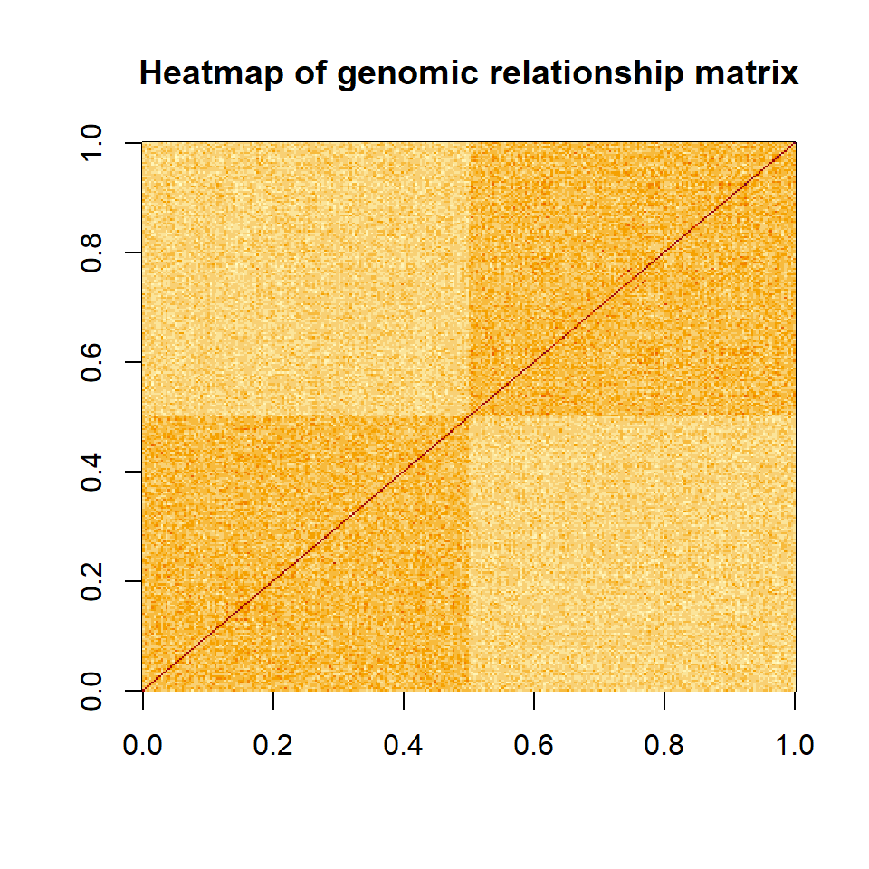

# Statistical model

- Linear model

$$y=Xb+Zu+e$$

$$y\sim N(Xb,V)$$

- Variances

$$Var(y)=V=ZGZ'+R$$

$$Var(u)=G=A\sigma^2_a$$

$$Var(e)=R=I\sigma^2_e$$

# Statistical model

The joint variance, including marker effects $\beta$, is defined as

$$Var\left[\begin{array}{r} y \\ u \\
\beta \\ e \end{array}\right] = \left[\begin{array}{rrrr} V & ZG
& Z\tilde{Z}D & R \\ GZ' & G & \tilde{Z}D & 0 \\
D\tilde{Z}'Z' & D\tilde{Z}' & D & 0 \\ R &
0 & 0 & R \end{array}\right]$$

where $u=\tilde{Z}\beta$, $\beta\sim N(0,D)$, $D=I_m\sigma^2_\beta$, and $G=A'\sigma^2_u=\tilde{Z}D\tilde{Z}'$. The model could be described as:

$$y=Xb+Z(\tilde{Z}\beta)+e$$

# Matrices - Design matrices

```r
y = Obs$YLD
X = model.matrix(~Block+Block:Sp-1,Obs)
Z = model.matrix(~ID-1,Obs)

# Constants
n = length(y) # number of obs
q = ncol(Z) # levels of Z
rX = ncol(X) # rank of X

# If you are not sure X is full-rank, run
# rX = qr(X)$rank

# Check dimensions
print(c(n=n,q=q,rX=rX))
```

```
##    n    q   rX
## 1117  280   18
```

# Matrices - Variance starting values

Let’s assume a starting values of $h_0^2\cong0.25$. Now what?

If $\hat{\sigma}^2_{Y0}=\frac{(y-Xb_{LS})'(y-Xb_{LS})}{n-r_X}$. Then,

$\hat{\sigma}^2_{e} = (1-h_0^2)\hat{\sigma}^2_{Y0}$ and $\hat{\sigma}^2_{e} = h_0^2\frac{\hat{\sigma}^2_{Y0}}{\sum^q_{j=1}{\sigma^2_{z_j}}}$.

```r
# Starting values for variance components
b = qr.solve(X,y)
vy0 = c(crossprod(y-X%*%b)/(n-rX))
vu = 0.25*vy0/sum(apply(Z,2,var))
ve = 0.75*vy0
vc = c(vu=vu,ve=ve)
print(vc)
```

```
##       vu       ve
## 15.42179 46.14134
```

# Matrices - Variance-covariances

```r
I = diag(n)
R = I*ve
G = A*vu
ZAZ = Z %*% A %*% t(Z)
V = Z%*%G%*%t(Z) + R
iG = solve(G)
iR = solve(I*ve)
iV = solve(V)
```

# Henderson’s equation

- Henderson’s mixed model equation (HMME) for

$$y=Xb+Zu+e$$

$$\left[\begin{array}{rr}X'R^{-1} X & Z'R^{-1}X
\\X'R^{-1}Z & Z'R^{-1}Z+G^{-1}\end{array}\right]
\left[\begin{array}{r} \hat{b} \\ \hat{u} \end{array}\right]
=\left[\begin{array}{r} X'R^{-1}y \\ Z'R^{-1}y
\end{array}\right]$$

$$\left[\begin{array}{rr} C_{11} & C_{12} \\ C_{21}&
C_{22}\end{array}\right]
\left[\begin{array}{r} \hat{g}_1 \\ \hat{g}_2 \end{array}\right]
=\left[\begin{array}{r} r_1 \\ r_2 \end{array}\right]$$

$$C\hat{g}=r$$

where $C$ is the *left-hand side*, $r$ is the *right-hand side*.

# Henderson’s equation

$$y=Xb+Zu+e$$

Alternative notation

$$y=Wg+e$$

where $W=\{X,Z\}$, and $g=\{b,u\}$. Thus, MME

$$[W'R^{-1}W+\Sigma] \hat{g} =
W'R^{-1}y$$

where

$$\Sigma= \left[\begin{array}{rr} 0 &
0 \\ 0 & G^{-1}\end{array}\right]$$

# Henderson’s equation

System of equations

```r
Sigma = Matrix::bdiag(diag(0,rX),iG)
W = cbind(X,Z)
C = t(W) %*% iR %*% W + Sigma
iC = solve(C)
r = t(W) %*% iR %*% y
```

Compute coefficients

```r
g = iC %*% r
b = g[1:rX]
u = g[-c(1:rX)]
```

# Reduced animal model

The “reduced animal model” simplifies the mixed model equation

$$\left[\begin{array}{rr}X'R^{-1} X & Z'R^{-1}X
\\X'R^{-1}Z & Z'R^{-1}Z+G^{-1}\end{array}\right]
\left[\begin{array}{r} \hat{b} \\ \hat{u} \end{array}\right]
=\left[\begin{array}{r} X'R^{-1}y \\ Z'R^{-1}y
\end{array}\right]$$

into

$$\left[\begin{array}{rr}X'X & Z'X \\X'Z &
Z'Z+\lambda A^{-1}\end{array}\right]
\left[\begin{array}{r} \hat{b} \\ \hat{u} \end{array}\right]
=\left[\begin{array}{r} X'y \\ Z'y \end{array}\right]$$
where $\lambda=\sigma^{2}_e\sigma^{-2}_u$.

That is achieved by multiplying every thing by $\sigma^{2}_e$.

# Reduced animal model

From a data-augmentation standpoint, the reduced model is:

$$\left[\begin{array}{rr}X'X & Z'X \\ X'Z & Z'Z
\\ 0 & \lambda A^{-1} \end{array}\right]
\left[\begin{array}{r} \hat{b} \\ \hat{u} \end{array}\right]
=\left[\begin{array}{r} X'y \\ Z'y \\ 0 \end{array}\right]$$

# Variance of BLUEs

Let $C^{-1}$ be described as

$$C^{-1} = \left[\begin{array}{rr} C^{11} & C^{12} \\ C^{21}&
C^{22}\end{array}\right]$$
Useful because

$$Var(\hat{b}) = C^{11} =
(X'V^{-1}X)^{-1}$$

Also, we’ll need $C^{22}$ to estimate variances later

```r
C22 = as.matrix(iC[-c(1:rX),-c(1:rX)])
```

# Projection matrices

LS absorption

$$S=I-X(X'X)^{-1}X'$$

BLUE absorption

$$M=I-X(X' V^{-1}
X)^{-1}X'V^{-1}$$
Random effect absorption

$$V^{-1}=R^{-1}-R^{-1}Z(Z'R^{-1}Z+G^{-1})^{-1}Z'R^{-1}$$

Mixed model absorption

$$P=V^{-1}-V^{-1}X(X' V^{-1}
X)^{-1}X'V^{-1}$$

# Projection matrices

$$H=WC^{-1}W'R^{-1}$$
$$Hy=\hat{y}$$
$$P=R^{-1}(I-H)$$

```r
S = I - X %*% solve( t(X)%*%X ) %*% t(X)
M = I - X %*% solve( t(X) %*% iV %*%X ) %*% t(X) %*% iV
P = iV %*% M
H = W %*% iC %*% t(W) %*% iR
yHat = H %*% y
e = y - yHat
```

# Projection matrices - Identities

$$SX = 0$$
$$PX = 0$$
$$SS =
S$$
$$MX = 0$$

$$My = y-X\hat{b}$$
$$MM = M$$
$$MS =
M$$
$$SM = S$$
$$PVP = P$$
$$P=V^{-1}M$$
$$P=(XX'\sigma^2_\infty+V)^{-1}$$
$$ZAZ'Py=\frac{Z\hat{u}}{\hat{\sigma}^2_u}$$
$$Py=\frac{\hat{e}}{\hat{\sigma}^2_e}$$

# BLUP solutions

$$\hat{u}=\hat{g}_2$$

$$\hat{u}=GZ'Py$$
$$\hat{u}=(Z'R^{-1}Z+G^{-1})^{-1}Z'R^{-1}(y-X\hat{b})$$

$$\hat{u}=(Z'Z+\sigma^{2}_e\sigma^{-2}_u
A^{-1})^{-1}Z'(y-X\hat{b})$$

# BLUP solutions

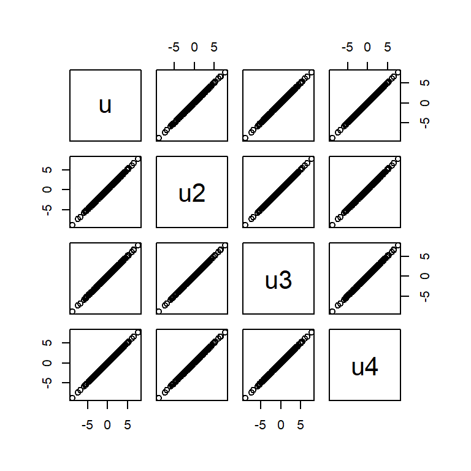

```r
# Other ways to get BLUPs
u2 = G %*% t(Z) %*% P %*% y
u3 = solve( t(Z)%*%iR%*%Z + iG , t(Z)%*%iR%*%c(y-X%*%b) )
u4 = solve( t(Z)%*%Z + iA*(ve/vu) , t(Z)%*% c(y-X%*%b) )
plot(data.frame(u,u2,u3,u4))
```

# Variance of BLUPs

The variance of $u$ is

$$Var(u)=G$$

However, the variance of $\hat{u}$

$$Var(\hat{u})=G Z' P Z G$$

Or, in terms of C,

$$Var(\hat{u})=G - C^{22}$$

# Variance of BLUPs

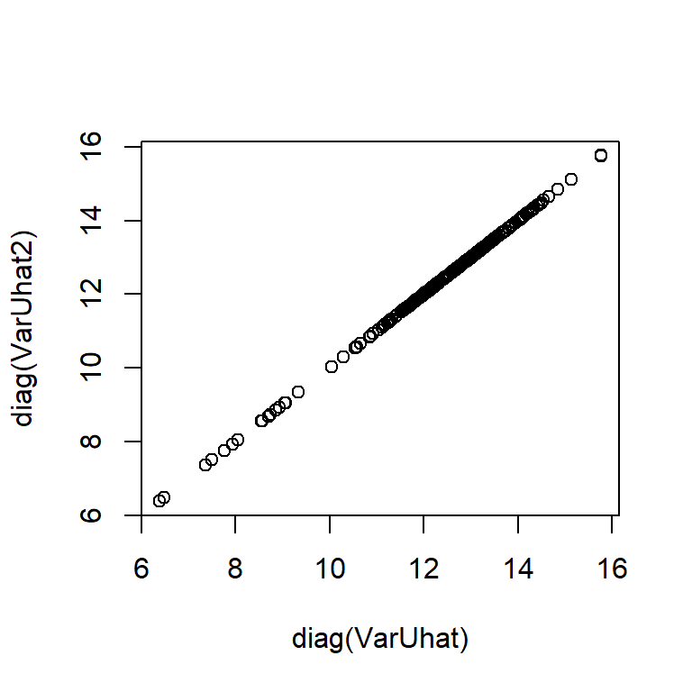

```r
# Variance of u hat
VarUhat = G %*% t(Z) %*% P %*% Z %*% G
VarUhat2 = G - C22
plot(diag(VarUhat),diag(VarUhat2))
```

# Reliability

Reliability is the observation-level heritability ($r^2$)

Under ML

$$r^2= Z' V^{-1} Z G$$

Under REML

$$r^2= I-C^{22}G^{-1}$$

# Reliability

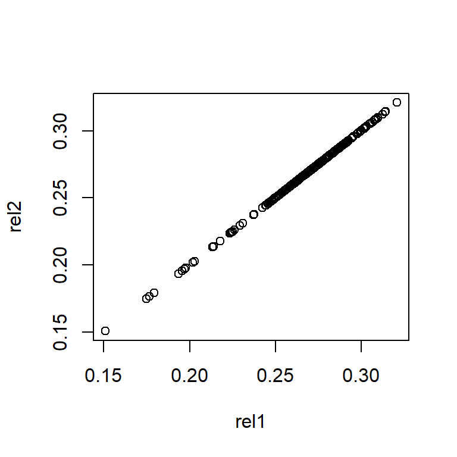

```r
rel1 = diag(diag(q)-C22 %*% iG)
rel2 = diag( t(Z) %*% P %*% Z %*% G )
plot(rel1,rel2)
```

# Accuracy

Accuracy is the square root of reliability ($a=\sqrt{r^2}$). Accuracy is generally defined as the correlation between estimated and true breeding values.

$$a = cor(u,\hat{u}) =
\frac{cov(u,\hat{u})}{sd(u)\times sd(\hat{u})}$$

If the statistical model is the true model, $\sigma^2_i=\hat{\sigma}^2_i$

$$a_i = \sqrt
\frac{cov(u,\hat{u})^2}{var(\hat{u})} = \sqrt{\frac{ G_{iy} Z'
V^{-1} Z G_{yi} }{ G_{ii} }}$$
When all individuals are observed, the denominator $G_{ii}$ cancels out with the nominator $G_{iy}$, yielding $a=\sqrt{Z' V^{-1} Z G}$.

# Accuracy

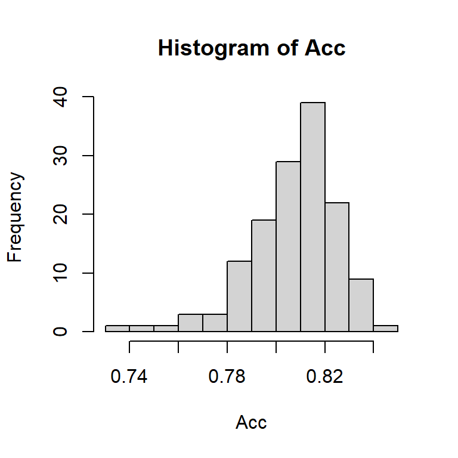

```r
R2_by_ind = function(z){  Cov12=(z%*%t(Z1)*alpha)*vu
  Var22 = c(crossprod(z)*alpha)*vu
  R2 = Cov12%*%t(Z)%*%iV%*%Z%*%t(Cov12)/Var22}
Acc = sqrt(apply(Z2,1,R2_by_ind)); hist(Acc)
```

# REML

Gaussian likelihood

$$L(X|\theta)=\frac{ exp
(y-Xb)'V^{-1}(y-Xb)}{2\pi |V|}$$

Log-likelihood

$$-2LL(X|\theta)= ln|V| +
(y-Xb)'V^{-1}(y-Xb)$$

Restricted Log-likelihood (REML)

$$-2LL(X|\theta)= ln|V| +
ln|X'V^{-1}X| + (y-Xb)'V^{-1}(y-Xb)$$

REML derived as pseudo-random

$$-2LL(X|\theta)= ln|P| +
y'Py$$

# Expectation-Maximization

We EM simply by rearranging $\partial L / \partial\sigma^2_i$.

Genetic variance

$$\partial L / \partial\sigma^2_u = tr(P
ZAZ') - y'PZAZ'Py$$

$$\partial L / \partial\sigma^2_u =
\frac{q}{\sigma^2_u} - \frac{u'A^{-1}u}{\sigma^4_u}-
\frac{tr(A^{-1}C^{22})}{\sigma^4_u}$$

Residual variance

$$\partial L / \partial\sigma^2_e = tr(P
I) - y'PIPy = tr(P) - y'P^2y$$

$$\partial L / \partial\sigma^2_e =
\frac{n-r_X}{\sigma^2_e} - \frac{q}{\sigma^2_e} -
\frac{tr(A^{-1}C^{22})}{\sigma^2_e\sigma^2_u}-
\frac{e'e}{\sigma^4_e}$$

# Expectation-Maximization

The final estimators turn out:

$$\hat{\sigma}^2_u=\frac{\hat{u}'A^{-1}\hat{u}+tr(A^{-1}C^{22})}{q}
= \frac{\hat{u}'A^{-1}\hat{u}}{q-tr(G^{-1}C^{22}) }$$

$$\hat{\sigma}^2_e=\frac{\hat{e}'\hat{e}+tr(WC^{-1}W')\hat{\sigma}^2_e}{n}=\frac{y'e}{n-r_X}$$

# Expectation-Maximization

```r
# Var e
Ve = c(crossprod(y,e)) / (n-rX)
# Var U
Vu = c(t(u) %*% iA %*% u + tr(iA%*%C22)) / q
# Var U (faster converging alternative)
Vu2 = c(t(u) %*% iA %*% u) / ( q - tr(iG%*%C22) )
# Check
print(c(Ve=Ve, Vu=Vu, Vu2=Vu2))
```

```
##       Ve       Vu      Vu2
## 52.18652 14.67906 12.66814
```

# Pseudo-Expectation

Simplification of the likelihood. From

$$\partial L / \partial\sigma^2_i = tr(P
V_i ) - y'PV_i'Py$$
To

$$\partial PL / \partial\sigma^2_i = tr(S
V_i ) - y'SV_i'Py$$

Yielding ([Schaeffer 1986](https://www.sciencedirect.com/science/article/pii/S0022030286807433), [VanRaden 1988](https://www.sciencedirect.com/science/article/pii/S0022030288795417)):

$\hat{\sigma}^2_u=\frac{ \tilde{u}'\hat{u}}{tr(AZ'SZ)}$ and $\hat{\sigma}^2_e=\frac{y'S'\hat{e}}{n-r_X}$

where $\tilde{u} = ySZ$.

# Pseudo-Expectation

```r
Sy = S %*% y
ZSy = t(Z) %*% Sy
trAZSZ = tr( S %*% ZAZ ) # In practice, only diagonals are computed
# Var U
c(u %*% ZSy) / trAZSZ
```

```
## [1] 9.506624
```

```r
# Var E
c(t(e) %*% Sy) / (n-rX)
```

```
## [1] 52.18652
```

**P.S.**: Pseudo-Expectation works great for SNP-BLUP.

# MIVQUE

Minimum Variance Quadratic Unbiased Estimator ([Rao 1971](https://www.sciencedirect.com/science/article/pii/0047259X71900194)):

- Unbiased variances: $E[\hat{\sigma}]=\sigma$
- Quadratic unbiasedness: $E[y'Qy]=E[\epsilon_i'Q\epsilon_i]=0$
- Invariant: $QX=0$
- $y'Qy=y'Q\epsilon_0+y'Q\epsilon_1$ where $\epsilon_0=e$ and $\epsilon_1=Zu$.
- Iterations of MIVQUE yields REML, we use $Q=P$.
- General formulation:

$$\hat{\sigma}=S^{-1}q$$
Where $S$ and $q$ are defined next.

# MIVQUE

$$\hat{\sigma}=S^{-1}q$$
Terms are defined as

$$S = \left[\begin{array}{rr}
P\frac{\partial V}{\partial\sigma^2_u}P\frac{\partial
V}{\partial\sigma^2_u} & P\frac{\partial
V}{\partial\sigma^2_u}P\frac{\partial V}{\partial\sigma^2_e} \\
P\frac{\partial V}{\partial\sigma^2_e}P\frac{\partial
V}{\partial\sigma^2_u} & P\frac{\partial
V}{\partial\sigma^2_e}P\frac{\partial V}{\partial\sigma^2_e}
\end{array}\right]$$

$$q = \left[\begin{array}{rr} y'P
\frac{\partial V}{\partial\sigma^2_u} Py \\ y'P \frac{\partial
V}{\partial\sigma^2_e} Py \end{array}\right]$$

where $\frac{\partial V}{\partial\sigma^2_u}=ZAZ'$ and $\frac{\partial V}{\partial\sigma^2_e}=I$

# MIVQUE

```r
PZAZ = P %*% ZAZ
S = matrix(c(
  tr( PZAZ %*% PZAZ ),    tr( PZAZ %*% P ),
  tr( P %*% I %*% PZAZ ), tr( P %*% P    )),2,2)
qs = c(Vu = c(t(y) %*% PZAZ %*% P %*% y),
       Ve = c(t(y) %*% P %*% P %*% y))
solve(S,qs)
```

```
## [1]  8.495934 54.161688
```

# Average-Information

Second-derivative methods (NR, FS, AI) work with:

$$\theta^{t+1} =
\theta^{t}-\frac{f'}{f''}$$

Where $f'$ and $f''$ are first and second derivatives, respectively. Where $f'=\Delta(\theta)$ is computed as

$$\Delta(\sigma^2_i) = \partial L /
\partial\sigma^2_i = tr(P \frac{\partial V}{\partial\sigma^2_i} ) -
y'P \frac{\partial V}{\partial\sigma^2_i}Py$$

And the ([average-Information](https://www.sciencedirect.com/science/article/pii/S0022030295766541)) $f''=AI(\theta)$ is computed as:

$$AI(\sigma^2_i,\sigma^2_j) =
y'P\frac{\partial V}{\partial\sigma^2_i} P\frac{\partial
V}{\partial\sigma^2_j} P y$$

# Average-Information

```r
SecDer1 = matrix(c(
  t(y)%*%PZAZ%*%PZAZ%*%P%*%y, t(y)%*%PZAZ%*%P%*%P%*% y,
  t(y)%*%P%*%PZAZ%*%P%*%y, t(y) %*%P%*%P%*%P%*%y ),2,2)
FirDer1 = c( vu = tr(PZAZ) - t(y) %*% PZAZ %*% P %*% y ,
             ve = tr(P %*% I) - t(y) %*% P %*% P %*% y )
vc - solve(SecDer1,FirDer1)
```

```
##        vu        ve
##  5.614032 53.308581
```

```r
SecDer1 # AI matrix
```

```
##            [,1]       [,2]
## [1,] 0.12285971 0.04612028
## [2,] 0.04612028 0.53927449
```

# Average-Information

Building $V$ and $P$ is often **not feasible**. Let’s check how to solve using the mixed model equations ([Meyer 1997](https://gsejournal.biomedcentral.com/articles/10.1186/1297-9686-29-2-97)). We have seen solutions for first derivative, $\Delta(\theta)$, through $C$:

$$\partial L / \partial\sigma^2_u =
\frac{q}{\sigma^2_u} - \frac{u'A^{-1}u}{\sigma^4_u}-
\frac{tr(A^{-1}C^{22})}{\sigma^4_u}$$

$$\partial L / \partial\sigma^2_e =
\frac{n-r_X}{\sigma^2_e} - \frac{q}{\sigma^2_e} -
\frac{tr(A^{-1}C^{22})}{\sigma^2_e\sigma^2_u}-
\frac{e'e}{\sigma^4_e}$$

# Average-Information

The $AI(\theta)$ is obtained as follows.

$$M_B = \left[\begin{array}{rr} C &
W'R^{-1}B \\ B'R^{-1}W & B'R^{-1}B
\end{array}\right]$$

$$B = \left[\begin{array}{r} ZAZ'Py
& Py \end{array}\right] = \left[\begin{array}{r} Zu\sigma^{-2}_u
& e\sigma^{-2}_e \end{array}\right]$$

Take the Cholesky

$$M_B = LL'$$

Then we reconstruct the sub-matrix corresponding to $B'R^{-1}B$.

$$AI(\theta) =
L_{22}'L_{22}$$

# Average-Information

```r
B = cbind( vu = Z %*% u / vu, ve = e / ve )
MB = chol(rbind(cbind(as.matrix(C),       t(W) %*% iR %*% B),
                cbind( t(B) %*% iR %*% W, t(B) %*% iR %*% B)))
LB = MB[(ncol(MB)-1):ncol(MB),(ncol(MB)-1):ncol(MB)]
SecDer2 =crossprod(LB)
FirDer2 =c(q/vu-(t(u)%*%iA%*%u)/(vu^2)-tr(iA%*%C22)/(vu^2),
    ((n-rX)/ve-(1/ve)*(q-tr(iA%*%C22)/(vu)))-crossprod(e)/(ve^2))
vc - solve(SecDer2,FirDer2)
```

```
##        vu        ve
##  5.614032 53.308581
```

```r
SecDer2 # AI matrix
```

```
##
##  0.12285971 0.04612028
##  0.04612028 0.53927449
```

# Gibbs sampling

Simple Hierarchical Bayesian approach to estimate variance components, where the final estimates are the **average** of the samples *a posteriori*, $\pi(\theta|x)$, the distribution of parameters ($\theta=\{\sigma^2_u,\sigma^2_u,b,u\}$) given data ($x=\{y,X,Z,A\}$). The posterior is a function of the probability of the data, $p(x|\theta)$, and probability of priors, $\pi(\theta)$.

$$\pi(\theta|x)\propto
p(x|\theta)\pi(\theta)$$

$$p(x|\theta)=N(Xb+Zu,R)N(u,G|\sigma^2_u)N(e,R|\sigma^2_e)$$
$$\pi(\theta)=\chi^{-2}(\sigma^2_u|S_u,\nu_u)\chi^{-2}(\sigma^2_e|S_e,\nu_e)$$

# Gibbs sampling

We sample variance components from a scaled inverse-chi square distribution:

$$\sigma^2_u|u,S_u,\nu_u \sim
\frac{u'A^{-1}u+S_u\nu_u}{\chi^2(q+\nu_u)}$$
$$\sigma^2_e|e,S_e,\nu_e \sim
\frac{e'e+S_e\nu_e}{\chi^2(n+\nu_e)}$$
Using the mixed model equation ($Cg=r$) notation, we sample coefficients from:

$$g_j|x,g_{-j} \sim N( \frac{r_j -
C_{-j,j}g_{-j}}{C_{j,j}},\frac{1}{C_{j,j}} )$$

# Gibbs sampling

```r
# Priors
df0 = 5
Su = vu
Se = ve
# Sample genetic variance
c(t(u) %*% iA %*% u + Su*df0 ) / rchisq(1,q+df0)
```

```
## [1] 3.835608
```

```r
# Sample residual variance
c(t(e) %*% e + Se*df0 ) / rchisq(1,n+df0)
```

```
## [1] 48.64093
```

# Gibbs sampling

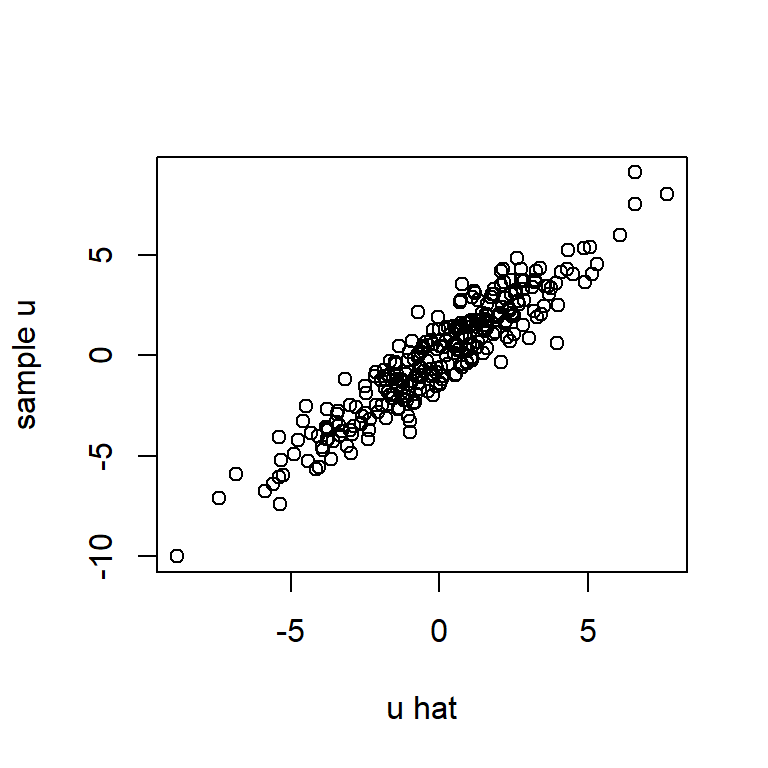

```r
g_samp = sapply(1:(rX+q), function(j) rnorm(n=1,
        mean=c(r[j]-C[j,-j]%*%g[-j])/C[j,j], sd=sqrt(1/C[j,j])))
plot(g[-c(1:rX)],g_samp[-c(1:rX)],xlab='u hat',ylab='sample u')
```

# Marker effects

$$\hat{\beta}|\hat{u}=\hat{\sigma}^2_\beta
\tilde{Z}'G^{-1}\hat{u}$$

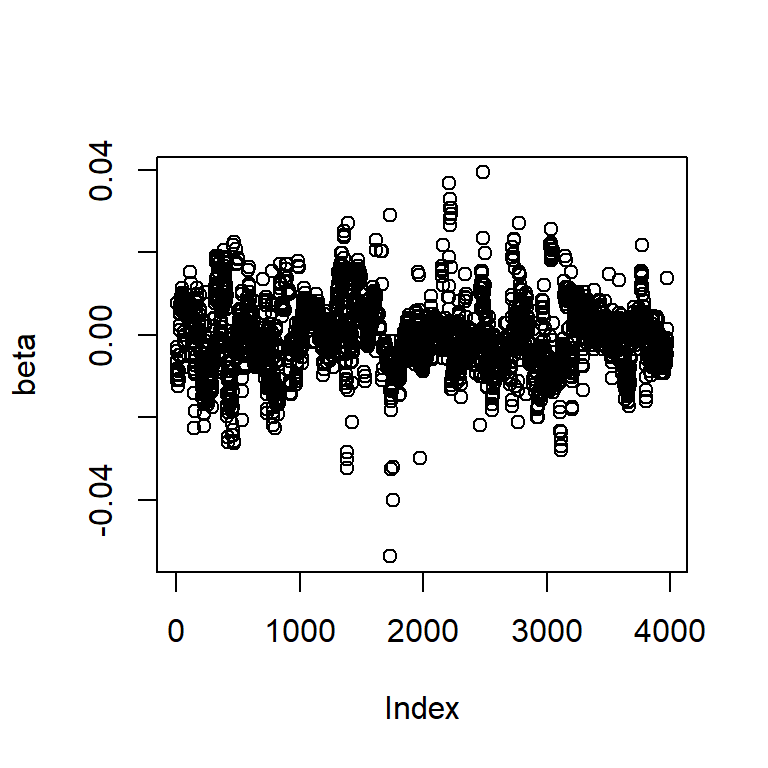

```r
vb = vu * alpha
beta = vb * c( t(Z1) %*% iG %*% u)
plot(beta)
```

# Final remarks

- Design matrices ($Z$,$X$) as sparse (*Matrix* pkg)
- Symmetric matrices ($C$,$C^{-1}$,$A^{-1}$) are store are upper diagonals
- Implement with good linear algebra libraries (*RcppEigen*, *RcppArmadillo*)
- Same matrices are never computed ($P$,$V$,$R$,$A$)
- When only traces are needed, only diagonals are computed (e.g., $tr(Z'SZ)$)
- Absorption can be efficiently done one vector at a time (e.g., $SZ$)
- Factorization can help in specific situations (SVD, EVD, Cholesky)